# Tutorial 5: Trajectory Selection

History matching identifies the **NROY region** — the part of parameter space *Not Ruled Out Yet* by the available evidence. But for stochastic models, knowing *which parameters are plausible* is only half the story. The same parameters with different random seeds can produce very different epidemic curves.

**Trajectory selection** is the post-calibration step that picks specific `(parameter set, random seed)` pairs whose simulated outputs are consistent with the observed data. The result is a set of **plausible trajectories** — not just plausible parameters.

This tutorial uses **Sampling Importance Resampling (SIR)**¹ to select trajectories:

1. Sample `(β, γ, seed)` triples from the NROY region
2. Run the stochastic simulator for each triple → get an ensemble of incidence curves
3. Weight each trajectory by how well it matches the observations (pseudo-likelihood)
4. Resample proportional to those weights → the selected trajectory set

¹ *Yes, the acronym matches the epidemic model. This is intentional and delightful.*

```python
import numpy as np
import pandas as pd
import matplotlib.pyplot as plt
import matplotlib.colors as mcolors

import historymatching as hm
from model import SIR, generate_observed_data

%matplotlib inline
```

[output not shown]

[output not shown]

## 1. Generate synthetic observations

We generate a synthetic epidemic using a known `(β, γ)` pair. In a real study this would be replaced by actual surveillance data.

```python
POPULATION       = 5_000
SEED_INFECTIONS  = 50
BETA_TRUE        = 0.7
GAMMA_TRUE       = 0.4

obs_incidence, obs_model = generate_observed_data(
    beta_true        = BETA_TRUE,
    gamma_true       = GAMMA_TRUE,
    population_size  = POPULATION,
    n_seed_infections= SEED_INFECTIONS,
    seed=40,
)

print(f"True parameters:  β={BETA_TRUE}, γ={GAMMA_TRUE}  (R₀ ≈ {BETA_TRUE/GAMMA_TRUE:.2f})")
print(f"Observed peak:    {obs_incidence.max():.0f} cases on day {obs_incidence.argmax()}")
print(f"Total cases:      {obs_incidence.sum():.0f}  (attack rate {obs_incidence.sum()/POPULATION:.1%})")

fig, ax = plt.subplots(figsize=(8, 3))
ax.plot(obs_incidence.values, 'ko-', ms=4, lw=1.5, label='Observed incidence')
ax.set_xlabel('Day')
ax.set_ylabel('Daily new cases')
ax.set_title('Observed epidemic curve')
ax.legend()
ax.grid(ls=':')
fig.tight_layout()
```

```
True parameters:  β=0.7, γ=0.4  (R₀ ≈ 1.75)
Observed peak:    236 cases on day 12
Total cases:      2852  (attack rate 57.0%)
```

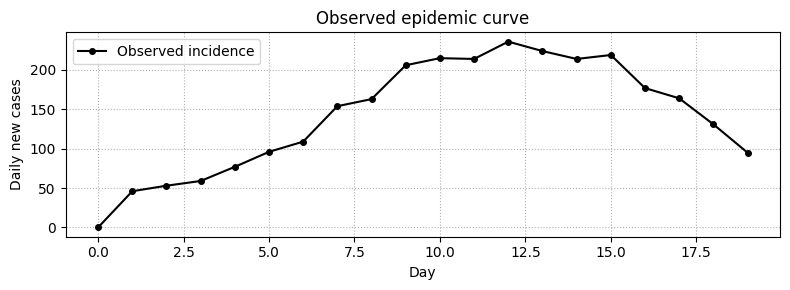

## 2. Run history matching to identify the NROY region

We calibrate using three summary statistics — peak incidence, attack rate, and incidence at day 5.

The simulation function **injects a `rand_seed`** column into the samples DataFrame if one isn't already present. Each `(β, γ, seed)` triple then maps to a single deterministic output, giving the GPR emulator a clean surface to fit. The engine ignores `rand_seed` for emulation (it only passes parameter-space columns to the emulator), but stores it on `result.samples` so the exact triples are available for trajectory selection later.

```python
def run_sir(samples: pd.DataFrame) -> pd.DataFrame:
    """Simulator wrapper — injects rand_seed for reproducibility.

    The engine only sees 'beta' and 'gamma' as parameter-space columns.
    'rand_seed' is metadata that flows through on result.samples.
    """
    df = samples.copy()
    if 'rand_seed' not in df.columns:
        df['rand_seed'] = np.random.default_rng(42).integers(0, 2**31, size=len(df))

    rows = []
    for _, row in df.iterrows():
        model = SIR(
            beta  = row['beta'],
            gamma = row['gamma'],
            s0    = POPULATION - SEED_INFECTIONS,
            i0    = SEED_INFECTIONS,
            seed  = int(row['rand_seed']),
        )
        inc = model.get_incidence()
        rows.append({
            'peak_incidence': float(inc.max()),
            'attack_rate':    float(inc.sum() / POPULATION),
            'incidence_5':    float(inc[5]) if len(inc) > 5 else 0.0,
        })
    return pd.DataFrame(rows)
```

```python
obs_peak  = float(obs_incidence.max())
obs_ar    = float(obs_incidence.sum() / POPULATION)
obs_inc5  = float(obs_incidence.values[5])

print(f"Observed peak:        {obs_peak:.0f} cases/day")
print(f"Observed incidence_5: {obs_inc5:.0f} cases/day")
print(f"Observed attack rate: {obs_ar:.2f}")

engine = hm.HistoryMatching(
    bounds = {'beta': (0.3, 2.0), 'gamma': (0.1, 0.8)},
    observations     = {
        'peak_incidence': (obs_peak,  obs_peak * 0.05),   # ±5%
        'attack_rate':    (obs_ar,    obs_ar   * 0.03),   # ±3%
        'incidence_5':    (obs_inc5,  obs_inc5 * 0.10),   # ±10%
    },
    function                 = run_sir,
    emulator_type            = 'gpr',
    n_samples                = 500,
    max_iterations           = 5,
    implausibility_threshold = 3.0,
)

results = engine.run()
print(engine)
```

```
Observed peak:        236 cases/day
Observed incidence_5: 96 cases/day
Observed attack rate: 0.57
```

[output not shown]

[output not shown]

[output not shown]

[output not shown]

[output not shown]

[output not shown]

[output not shown]

[output not shown]

[output not shown]

[output not shown]

[output not shown]

[output not shown]

[output not shown]

[output not shown]

[output not shown]

[output not shown]

[output not shown]

[output not shown]

[output not shown]

[output not shown]

[output not shown]

[output not shown]

[output not shown]

[output not shown]

[output not shown]

[output not shown]

[output not shown]

[output not shown]

[output not shown]

[output not shown]

[output not shown]

[output not shown]

[output not shown]

[output not shown]

[output not shown]

[output not shown]

[output not shown]

[output not shown]

[output not shown]

[output not shown]

[output not shown]

[output not shown]

[output not shown]

[output not shown]

[output not shown]

[output not shown]

[output not shown]

[output not shown]

[output not shown]

[output not shown]

[output not shown]

[output not shown]

[output not shown]

[output not shown]

[output not shown]

[output not shown]

[output not shown]

[output not shown]

[output not shown]

[output not shown]

[output not shown]

[output not shown]

[output not shown]

[output not shown]

[output not shown]

[output not shown]

[output not shown]

[output not shown]

[output not shown]

[output not shown]

[output not shown]

[output not shown]

[output not shown]

[output not shown]

[output not shown]

[output not shown]

[output not shown]

[output not shown]

[output not shown]

[output not shown]

[output not shown]

[output not shown]

[output not shown]

[output not shown]

[output not shown]

[output not shown]

[output not shown]

[output not shown]

[output not shown]

[output not shown]

[output not shown]

[output not shown]

[output not shown]

[output not shown]

[output not shown]

[output not shown]

[output not shown]

[output not shown]

[output not shown]

[output not shown]

[output not shown]

[output not shown]

[output not shown]

[output not shown]

[output not shown]

[output not shown]

[output not shown]

[output not shown]

[output not shown]

[output not shown]

[output not shown]

[output not shown]

[output not shown]

[output not shown]

[output not shown]

[output not shown]

[output not shown]

[output not shown]

[output not shown]

[output not shown]

[output not shown]

[output not shown]

[output not shown]

[output not shown]

[output not shown]

[output not shown]

[output not shown]

[output not shown]

[output not shown]

[output not shown]

[output not shown]

[output not shown]

[output not shown]

[output not shown]

[output not shown]

```
HistoryMatching(
  parameters=2 ['beta', 'gamma'],
  outputs=3 ['peak_incidence', 'attack_rate', 'incidence_5'],
  emulator=gpr, simulator=set,
  n_samples=500, implausibility_threshold=3.0,
  state=completed, wave 5/5, acceptance_rate=0.129
)
```

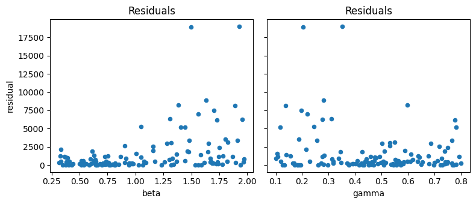

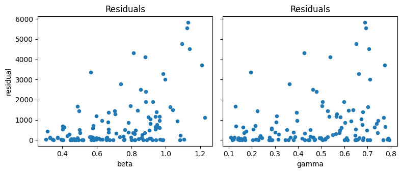

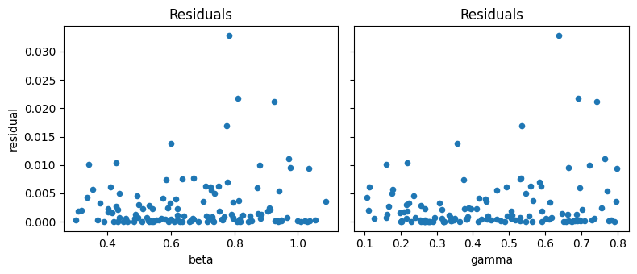

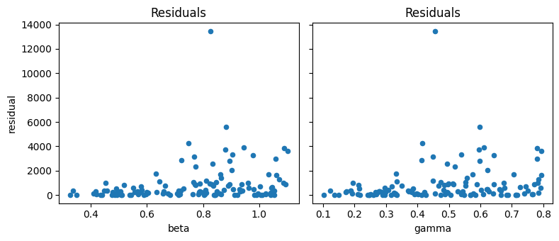

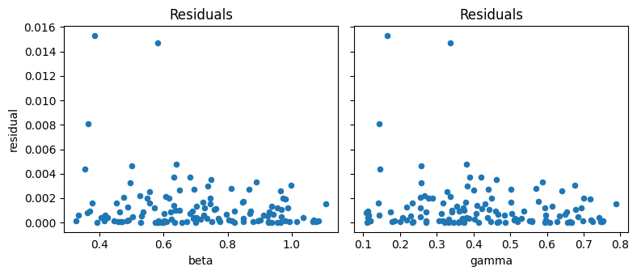